# Adding Hierarchy to the P/NBD Model

We now turn our attention to trying to capture our uncertainty in prior parameters by adding them to the model.

We first need to load our data.

```r
fit_1000_data_tbl  <- read_rds("data/fit_1000_longframe_data_tbl.rds")
fit_10000_data_tbl <- read_rds("data/fit_10000_longframe_data_tbl.rds")

customer_summarystats_tbl <- read_rds("data/customer_summarystats_longframe_tbl.rds")
customer_transactions_tbl <- read_rds("data/synthdata_longframe_transactions_tbl.rds")

obs_2019_stats_tbl <- read_rds("data/longframe_obs_2019_stats_tbl.rds")
```

# 1 Fit First Hierarchical Model

We now want to add a hierarchy to the model by adding hierarchical priors to our P/NBD model.

```r
stan_modeldir <- "stan_models"
stan_codedir  <-   "stan_code"
```

We start with our Stan model.

```
functions {
  #include util_functions.stan
}

data {
  int<lower=1> n;           // number of customers

  vector<lower=0>[n] t_x;   // time to most recent purchase
  vector<lower=0>[n] T_cal; // total observation time
  vector<lower=0>[n] x;     // number of purchases observed

  real<lower=0> lambda_mn;  // prior mean for lambda
  real<lower=0> lambda_cv;  // prior cv   for lambda

  real mu_mn_p1;           // hyperprior p1 for mu mean
  real<lower=0> mu_mn_p2;  // hyperprior p2 for mu mean

  real mu_cv_p1;           // hyperprior p1 for mu cv
  real<lower=0> mu_cv_p2;  // hyperprior p2 for mu cv
}

transformed data {
  real<lower=0> r       = 1 / (lambda_cv * lambda_cv);
  real<lower=0> alpha   = 1 / (lambda_cv * lambda_cv * lambda_mn);
}


parameters {
  real<lower=0> mu_mn;
  real<lower=0> mu_cv;

  vector<lower=0>[n] lambda; // purchase rate
  vector<lower=0>[n] mu;     // lifetime dropout rate
}


transformed parameters {
  real<lower=0> s;
  real<lower=0> beta;

  s    = 1 / (mu_cv * mu_cv);
  beta = 1 / (mu_cv * mu_cv * mu_mn);
}

model {
  // model the hyper-prior
  mu_mn ~ lognormal(mu_mn_p1, mu_mn_p2);
  mu_cv ~ lognormal(mu_cv_p1, mu_cv_p2);

  // setting priors
  lambda ~ gamma(r, alpha);
  mu     ~ gamma(s,  beta);

  target += calculate_pnbd_loglik(n, lambda, mu, x, t_x, T_cal);
}

generated quantities {
  vector[n] p_alive;         // Probability that they are still "alive"

  p_alive = 1 ./ (1 + mu ./ (mu + lambda) .* (exp((lambda + mu) .* (T_cal - t_x)) - 1));
}
```

This file contains a few new features of Stan - named file includes and user-defined functions - `calculate_pnbd_loglik`. We look at this file here:

```
real calculate_pnbd_loglik(int n, vector lambda, vector mu,
                           data vector x, data vector t_x, data vector T_cal) {
  // likelihood
  vector[n] t1;
  vector[n] t2;

  vector[n] lpm;
  vector[n] lht;
  vector[n] rht;

  lpm = lambda + mu;

  lht = log(lambda) - lpm .* T_cal;
  rht = log(mu)     - lpm .* t_x;

  t1  = x .* log(lambda) - log(lpm);

  for (i in 1:n) {
    t2[i] = log_sum_exp(lht[i], rht[i]);
  }

  return(sum(t1) + sum(t2));
}


real calculate_bgnbd_loglik(int n, vector lambda, vector p,
                            data vector x, data vector t_x, data vector T_cal) {
  // likelihood
  vector[n] t1;
  vector[n] t2;

  vector[n] lht;
  vector[n] rht;

  lht = log(p) + (x-1) .* log(1-p) + x .* log(lambda) - lambda .* t_x;
  rht = x .* log(1-p) + x .* log(lambda) - lambda .* T_cal;

  for(i in 1:n) {
    t2[i] = log_sum_exp(lht[i], rht[i]);
  }

  return(sum(t2));
}
```

We now compile this model using `CmdStanR`.

```r
pnbd_hiermu_stanmodel <- cmdstan_model(
  "stan_code/pnbd_hiermu.stan",
  include_paths =   stan_codedir,
  pedantic      =           TRUE,
  dir           =  stan_modeldir
  )
```

We then use this compiled model with our data to produce a fit of the data.

```r
stan_modelname <- "pnbd_hiermu"
stanfit_prefix <- str_c("fit_", stan_modelname)

stan_data_lst <- fit_1000_data_tbl %>%
  select(customer_id, x, t_x, T_cal) %>%
  compose_data(
    lambda_mn = 0.25,
    lambda_cv = 1.00,

    mu_mn_p1  = log(0.1) - 0.5 * (0.5)^2,
    mu_mn_p2  = 0.5,

    mu_cv_p1  = log(1) - 0.5 * (0.2)^2,
    mu_cv_p2  = 0.2,
    )

pnbd_hiermu_stanfit <- pnbd_hiermu_stanmodel$sample(
  data            =                stan_data_lst,
  chains          =                            4,
  iter_warmup     =                          500,
  iter_sampling   =                          500,
  seed            =                         4201,
  save_warmup     =                         TRUE,
  output_dir      =                stan_modeldir,
  output_basename =               stanfit_prefix,
  )
```

```
Running MCMC with 4 chains, at most 8 in parallel...

Chain 1 Iteration:   1 / 1000 [  0%]  (Warmup)
Chain 2 Iteration:   1 / 1000 [  0%]  (Warmup)
Chain 3 Iteration:   1 / 1000 [  0%]  (Warmup)
Chain 4 Iteration:   1 / 1000 [  0%]  (Warmup)
Chain 1 Iteration: 100 / 1000 [ 10%]  (Warmup)
Chain 2 Iteration: 100 / 1000 [ 10%]  (Warmup)
Chain 3 Iteration: 100 / 1000 [ 10%]  (Warmup)
Chain 4 Iteration: 100 / 1000 [ 10%]  (Warmup)
Chain 1 Iteration: 200 / 1000 [ 20%]  (Warmup)
Chain 2 Iteration: 200 / 1000 [ 20%]  (Warmup)
Chain 3 Iteration: 200 / 1000 [ 20%]  (Warmup)
Chain 4 Iteration: 200 / 1000 [ 20%]  (Warmup)
Chain 1 Iteration: 300 / 1000 [ 30%]  (Warmup)
Chain 2 Iteration: 300 / 1000 [ 30%]  (Warmup)
Chain 3 Iteration: 300 / 1000 [ 30%]  (Warmup)
Chain 4 Iteration: 300 / 1000 [ 30%]  (Warmup)
Chain 1 Iteration: 400 / 1000 [ 40%]  (Warmup)
Chain 2 Iteration: 400 / 1000 [ 40%]  (Warmup)
Chain 3 Iteration: 400 / 1000 [ 40%]  (Warmup)
Chain 4 Iteration: 400 / 1000 [ 40%]  (Warmup)
Chain 1 Iteration: 500 / 1000 [ 50%]  (Warmup)
Chain 1 Iteration: 501 / 1000 [ 50%]  (Sampling)
Chain 2 Iteration: 500 / 1000 [ 50%]  (Warmup)
Chain 2 Iteration: 501 / 1000 [ 50%]  (Sampling)
Chain 3 Iteration: 500 / 1000 [ 50%]  (Warmup)
Chain 3 Iteration: 501 / 1000 [ 50%]  (Sampling)
Chain 4 Iteration: 500 / 1000 [ 50%]  (Warmup)
Chain 4 Iteration: 501 / 1000 [ 50%]  (Sampling)
Chain 1 Iteration: 600 / 1000 [ 60%]  (Sampling)
Chain 2 Iteration: 600 / 1000 [ 60%]  (Sampling)
Chain 3 Iteration: 600 / 1000 [ 60%]  (Sampling)
Chain 4 Iteration: 600 / 1000 [ 60%]  (Sampling)
Chain 1 Iteration: 700 / 1000 [ 70%]  (Sampling)
Chain 2 Iteration: 700 / 1000 [ 70%]  (Sampling)
Chain 3 Iteration: 700 / 1000 [ 70%]  (Sampling)
Chain 4 Iteration: 700 / 1000 [ 70%]  (Sampling)
Chain 1 Iteration: 800 / 1000 [ 80%]  (Sampling)
Chain 2 Iteration: 800 / 1000 [ 80%]  (Sampling)
Chain 3 Iteration: 800 / 1000 [ 80%]  (Sampling)
Chain 4 Iteration: 800 / 1000 [ 80%]  (Sampling)
Chain 1 Iteration: 900 / 1000 [ 90%]  (Sampling)
Chain 2 Iteration: 900 / 1000 [ 90%]  (Sampling)
Chain 3 Iteration: 900 / 1000 [ 90%]  (Sampling)
Chain 4 Iteration: 900 / 1000 [ 90%]  (Sampling)
Chain 1 Iteration: 1000 / 1000 [100%]  (Sampling)
Chain 1 finished in 27.3 seconds.
Chain 2 Iteration: 1000 / 1000 [100%]  (Sampling)
Chain 2 finished in 27.3 seconds.
Chain 3 Iteration: 1000 / 1000 [100%]  (Sampling)
Chain 3 finished in 27.4 seconds.
Chain 4 Iteration: 1000 / 1000 [100%]  (Sampling)
Chain 4 finished in 27.3 seconds.

All 4 chains finished successfully.
Mean chain execution time: 27.3 seconds.
Total execution time: 28.5 seconds.
```

```r
pnbd_hiermu_stanfit$summary()
```

```
# A tibble: 3,005 × 10
   variable       mean   median      sd     mad       q5      q95  rhat ess_bulk
   <chr>         <dbl>    <dbl>   <dbl>   <dbl>    <dbl>    <dbl> <dbl>    <dbl>
 1 lp__       -1.40e+4 -1.40e+4 5.67e+1 5.46e+1 -1.41e+4 -1.39e+4 1.01      159.
 2 mu_mn       1.15e-1  1.15e-1 9.06e-3 9.29e-3  1.01e-1  1.31e-1 1.01      262.
 3 mu_cv       7.85e-1  7.84e-1 4.27e-2 4.34e-2  7.14e-1  8.56e-1 1.01      176.
 4 lambda[1]   1.95e-1  1.69e-1 1.21e-1 1.08e-1  4.75e-2  4.33e-1 0.999    3978.
 5 lambda[2]   3.45e-1  3.40e-1 6.20e-2 5.97e-2  2.50e-1  4.50e-1 1.00     3267.
 6 lambda[3]   1.39e-1  8.85e-2 1.59e-1 9.82e-2  5.13e-3  4.48e-1 1.00     2507.
 7 lambda[4]   3.65e-1  3.51e-1 1.16e-1 1.09e-1  2.00e-1  5.78e-1 1.00     3962.
 8 lambda[5]   1.44e-1  8.38e-2 1.76e-1 9.38e-2  5.37e-3  4.75e-1 0.999    3054.
 9 lambda[6]   1.46e-1  8.37e-2 1.76e-1 1.00e-1  5.00e-3  5.05e-1 1.00     2746.
10 lambda[7]   1.39e-1  1.37e-1 3.36e-2 3.41e-2  8.91e-2  1.98e-1 1.00     4115.
# … with 2,995 more rows, and 1 more variable: ess_tail <dbl>
```

We have some basic HMC-based validity statistics we can check.

```r
pnbd_hiermu_stanfit$cmdstan_diagnose()
```

```
Processing csv files: /home/rstudio/workshop/stan_models/fit_pnbd_hiermu-1.csvWarning: non-fatal error reading adaptation data
, /home/rstudio/workshop/stan_models/fit_pnbd_hiermu-2.csvWarning: non-fatal error reading adaptation data
, /home/rstudio/workshop/stan_models/fit_pnbd_hiermu-3.csvWarning: non-fatal error reading adaptation data
, /home/rstudio/workshop/stan_models/fit_pnbd_hiermu-4.csvWarning: non-fatal error reading adaptation data


Checking sampler transitions treedepth.
Treedepth satisfactory for all transitions.

Checking sampler transitions for divergences.
No divergent transitions found.

Checking E-BFMI - sampler transitions HMC potential energy.
E-BFMI satisfactory.

Effective sample size satisfactory.

Split R-hat values satisfactory all parameters.

Processing complete, no problems detected.
```

## 1.1 Visual Diagnostics of the Sample Validity

Now that we have a sample from the posterior distribution we need to create a few different visualisations of the diagnostics.

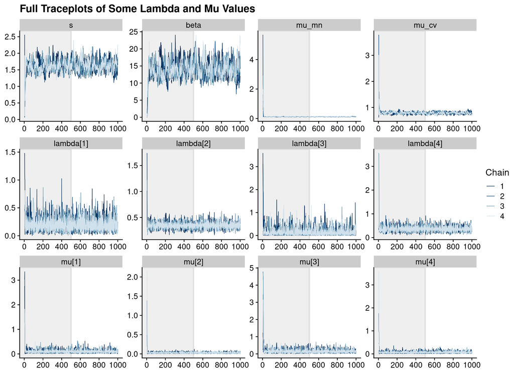

```r
parameter_subset <- c(
  "s", "beta", "mu_mn", "mu_cv",
  "lambda[1]", "lambda[2]", "lambda[3]", "lambda[4]",
  "mu[1]",     "mu[2]",     "mu[3]",     "mu[4]"
  )

pnbd_hiermu_stanfit$draws(inc_warmup = TRUE) %>%
  mcmc_trace(
    pars     = parameter_subset,
    n_warmup = 500
    ) +
  ggtitle("Full Traceplots of Some Lambda and Mu Values")
```

As the warmup is skewing the y-axis somewhat, we repeat this process without the warmup.

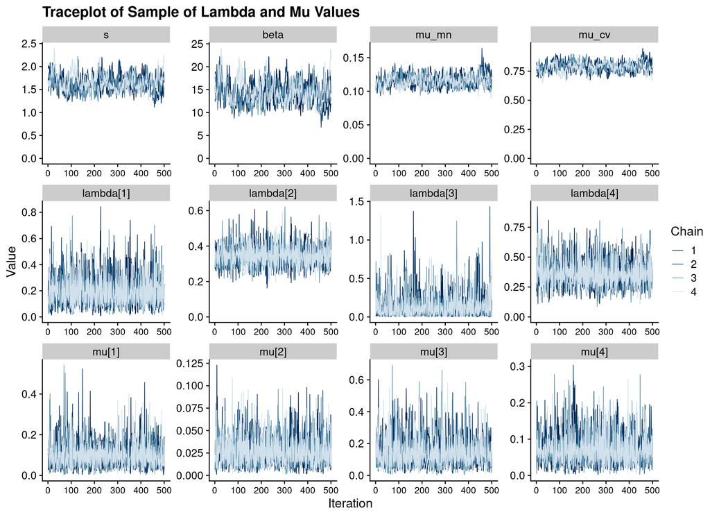

```r
pnbd_hiermu_stanfit$draws(inc_warmup = FALSE) %>%
  mcmc_trace(pars = parameter_subset) +
  expand_limits(y = 0) +
  labs(
    x = "Iteration",
    y = "Value",
    title = "Traceplot of Sample of Lambda and Mu Values"
    ) +
  theme(axis.text.x = element_text(size = 10))
```

A common MCMC diagnostic is $\hat{R}$ - which is a measure of the ‘similarity’ of the chains.

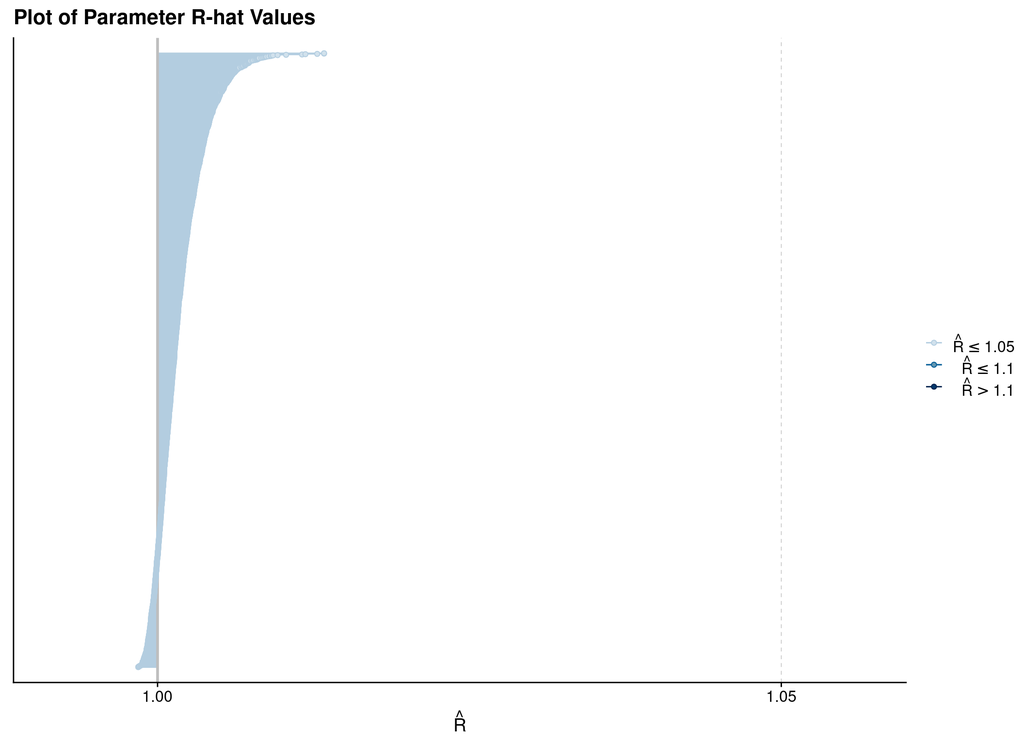

```r
pnbd_hiermu_stanfit %>%
  rhat(pars = c("lambda", "mu", "s", "beta", "mu_mn", "mu_cv")) %>%
  mcmc_rhat() +
    ggtitle("Plot of Parameter R-hat Values")
```

Related to this quantity is the concept of *effective sample size*, $N_{eff}$, an estimate of the size of the sample from a statistical information point of view.

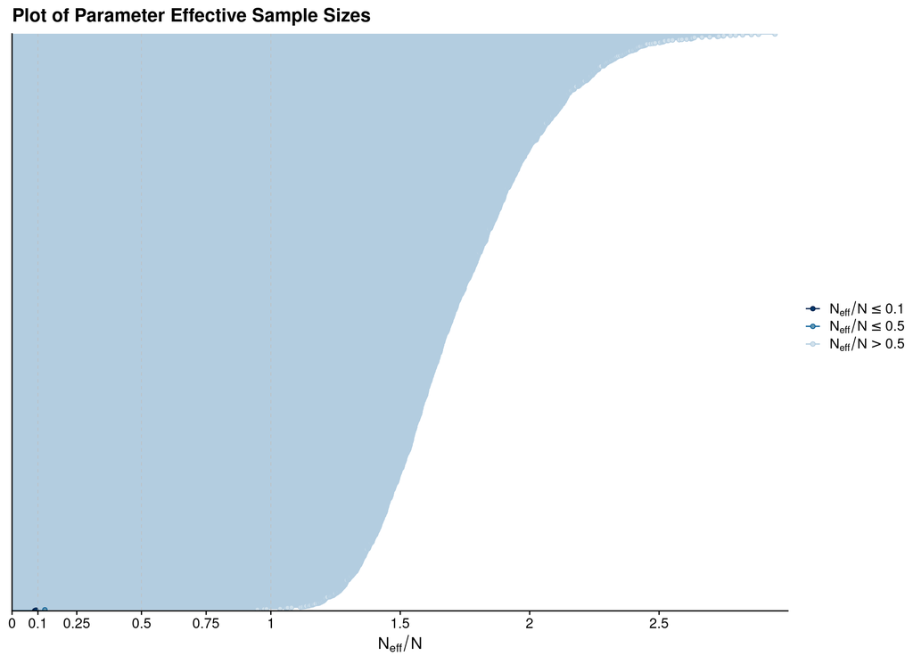

```r
pnbd_hiermu_stanfit %>%
  neff_ratio(pars = c("lambda", "mu", "s", "beta", "mu_mn", "mu_cv")) %>%
  mcmc_neff() +
    ggtitle("Plot of Parameter Effective Sample Sizes")
```

Finally, we also want to look at autocorrelation in the chains for each parameter.

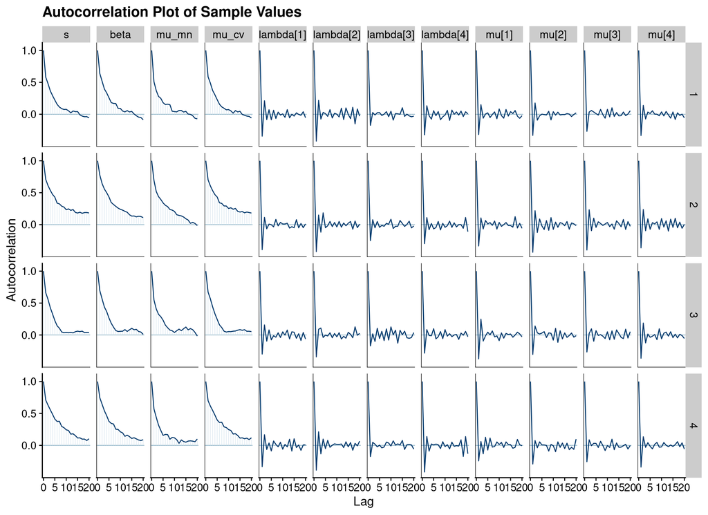

```r
pnbd_hiermu_stanfit$draws() %>%
  mcmc_acf(pars = parameter_subset) +
    ggtitle("Autocorrelation Plot of Sample Values")
```

As before, this first fit has a comprehensive run of fit diagnostics, but for the sake of brevity in later models we will show only the traceplots once we are satisfied with the validity of the sample.

## 1.2 Validate the Hier-Mu Model Fit

We now want to validate this model by using our simulation technique.

We first extract our posterior by customer, and use this as the basis of our simulations.

```r
pnbd_hiermu_validation_tbl <- pnbd_hiermu_stanfit %>%
  recover_types(fit_1000_data_tbl) %>%
  spread_draws(lambda[customer_id], mu[customer_id], p_alive[customer_id]) %>%
  ungroup() %>%
  select(customer_id, draw_id = .draw, post_lambda = lambda, post_mu = mu, p_alive)

pnbd_hiermu_validation_tbl %>% glimpse()
```

```
Rows: 2,000,000
Columns: 5
$ customer_id <chr> "C201101_0025", "C201101_0025", "C201101_0025", "C201101_0…
$ draw_id     <int> 1, 2, 3, 4, 5, 6, 7, 8, 9, 10, 11, 12, 13, 14, 15, 16, 17,…
$ post_lambda <dbl> 0.1314730, 0.2764690, 0.1216930, 0.2560520, 0.3791690, 0.1…
$ post_mu     <dbl> 0.1320430, 0.0795552, 0.1424040, 0.0274170, 0.1295670, 0.0…
$ p_alive     <dbl> 3.17970e-47, 2.65862e-63, 2.32973e-47, 4.71273e-50, 1.7695…
```

Having constructed our simulations inputs, we now generate our simulations.

```r
pnbd_hiermu_validsims_tbl <- pnbd_hiermu_validation_tbl %>%
  group_nest(customer_id, .key = "cust_params") %>%
  mutate(
    sim_file = glue(
      "precompute/pnbd_hiermu/sims_pnbd_hiermu_{customer_id}.rds"
      ),
    chunk_data = future_map2(
      sim_file, cust_params,
      run_pnbd_simulations_chunk,

      .options = furrr_options(
        globals  = c(
          "calculate_event_times", "rgamma_mucv", "gamma_mucv2shaperate",
          "generate_pnbd_validation_transactions"
          ),
        packages   = c("tidyverse", "fs"),
        scheduling = FALSE,
        seed       = 421
        ),
      .progress = TRUE
      )
    ) %>%
  select(-cust_params) %>%
  unnest(chunk_data)


pnbd_hiermu_validsims_tbl %>% glimpse()
```

```
Rows: 2,000,000
Columns: 9
$ customer_id   <chr> "C201101_0025", "C201101_0025", "C201101_0025", "C201101…
$ sim_file      <glue> "precompute/pnbd_hiermu/sims_pnbd_hiermu_C201101_0025.r…
$ draw_id       <int> 1, 2, 3, 4, 5, 6, 7, 8, 9, 10, 11, 12, 13, 14, 15, 16, 1…
$ post_lambda   <dbl> 0.1314730, 0.2764690, 0.1216930, 0.2560520, 0.3791690, 0…
$ post_mu       <dbl> 0.1320430, 0.0795552, 0.1424040, 0.0274170, 0.1295670, 0…
$ p_alive       <dbl> 3.17970e-47, 2.65862e-63, 2.32973e-47, 4.71273e-50, 1.76…
$ sim_data      <list> [<tbl_df[0 x 2]>], [<tbl_df[0 x 2]>], [<tbl_df[0 x 2]>]…
$ sim_tnx_count <int> 0, 0, 0, 0, 0, 0, 0, 0, 0, 0, 0, 0, 0, 0, 0, 0, 0, 0, 0,…
$ sim_tnx_last  <dttm> NA, NA, NA, NA, NA, NA, NA, NA, NA, NA, NA, NA, NA, NA,…
```

```r
pnbd_hiermu_1000_validation_tbl <- pnbd_hiermu_validsims_tbl %>%
  group_by(customer_id) %>%
  summarise(
    .groups = "drop",

    sim_count = list(map_int(sim_data, nrow))
    ) %>%
  left_join(obs_2019_stats_tbl, by = "customer_id") %>%
  replace_na(list(tnx_count = 0)) %>%
  mutate(
    tnx_count_qval = map2_dbl(sim_count, tnx_count, ~ ecdf(.x)(.y))
    )

pnbd_hiermu_1000_validation_tbl %>% glimpse()
```

```
Rows: 1,000
Columns: 6
$ customer_id    <chr> "C201101_0025", "C201101_0084", "C201101_0091", "C20110…
$ sim_count      <list> <0, 0, 0, 0, 0, 0, 0, 0, 0, 0, 0, 0, 0, 0, 0, 0, 0, 0,…
$ tnx_count      <int> 0, 0, 0, 0, 0, 0, 0, 0, 0, 0, 0, 0, 0, 0, 0, 0, 0, 0, 0…
$ first_tnx      <dttm> NA, NA, NA, NA, NA, NA, NA, NA, NA, NA, NA, NA, NA, NA…
$ last_tnx       <dttm> NA, NA, NA, NA, NA, NA, NA, NA, NA, NA, NA, NA, NA, NA…
$ tnx_count_qval <dbl> 1, 1, 1, 1, 1, 1, 1, 1, 1, 1, 1, 1, 1, 1, 1, 1, 1, 1, 1…
```

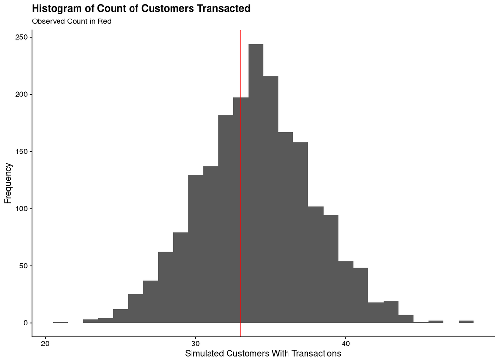

```r
tnx_data_tbl <- obs_2019_stats_tbl %>%
  semi_join(pnbd_hiermu_validsims_tbl, by = "customer_id")

obs_customer_count  <- tnx_data_tbl %>% nrow()
obs_total_tnx_count <- tnx_data_tbl %>% pull(tnx_count) %>% sum()

pnbd_hiermu_tnx_simsumm_tbl <- pnbd_hiermu_validsims_tbl %>%
  group_by(draw_id) %>%
  summarise(
    .groups = "drop",

    sim_customer_count  = length(sim_tnx_count[sim_tnx_count > 0]),
    sim_total_tnx_count = sum(sim_tnx_count)
    )


ggplot(pnbd_hiermu_tnx_simsumm_tbl) +
  geom_histogram(aes(x = sim_customer_count), binwidth = 1) +
  geom_vline(aes(xintercept = obs_customer_count), colour = "red") +
  labs(
    x = "Simulated Customers With Transactions",
    y = "Frequency",
    title = "Histogram of Count of Customers Transacted",
    subtitle = "Observed Count in Red"
    )
```

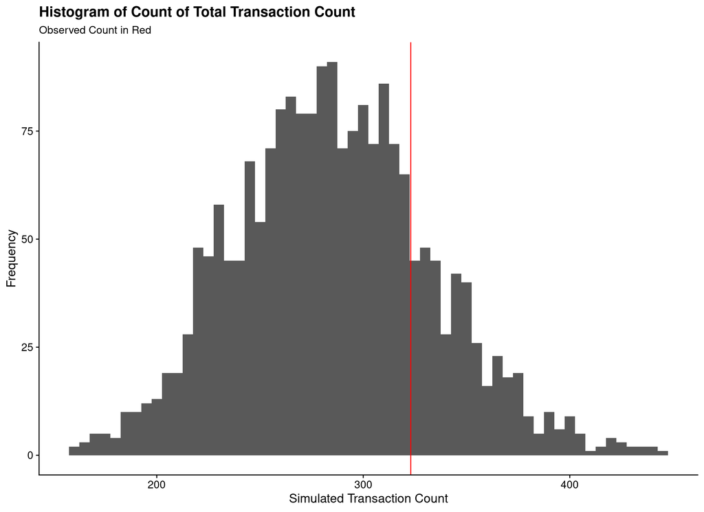

```r
ggplot(pnbd_hiermu_tnx_simsumm_tbl) +
  geom_histogram(aes(x = sim_total_tnx_count), binwidth = 5) +
  geom_vline(aes(xintercept = obs_total_tnx_count), colour = "red") +
  labs(
    x = "Simulated Transaction Count",
    y = "Frequency",
    title = "Histogram of Count of Total Transaction Count",
    subtitle = "Observed Count in Red"
    )
```

# 2 R Environment

```r
options(width = 120L)
```

```r
options(width = 80L)
```